# DS2 HW4

Mufeng Xu

4/8/2021

# Problem 1

## A. Regression tree

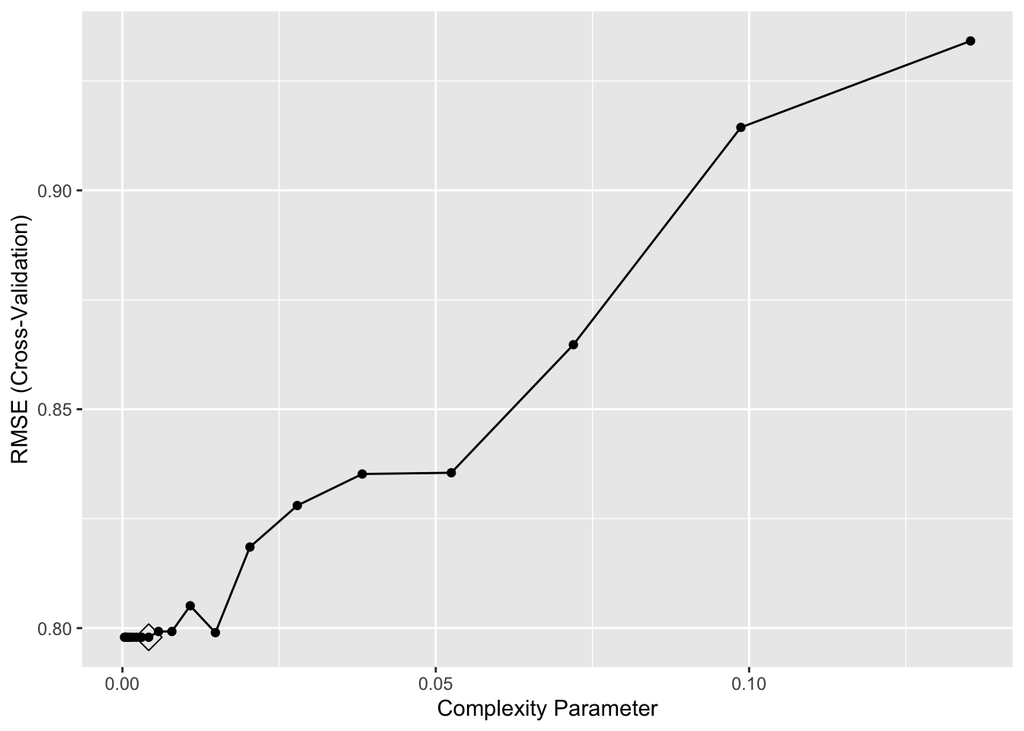

```r
data(Prostate)

# The lowest CV error
set.seed(1)

ctrl = trainControl(method = "cv")

tree_fit_1 = train(lpsa~.,
                   data = Prostate,
                   method = "rpart",
                   tuneGrid = data.frame(cp = exp(seq(-8,-2, length = 20))),
                   trControl = trainControl(method = "cv"))

ggplot(tree_fit_1, highlight = TRUE)
```

```r
tree_fit_1$bestTune
```

```
##            cp
## 9 0.004195746
```

```r
tree_fit_1$finalModel$cptable
```

```
##           CP nsplit rel error
## 1 0.34710828      0 1.0000000
## 2 0.18464743      1 0.6528917
## 3 0.05931585      2 0.4682443
## 4 0.03475635      3 0.4089284
## 5 0.03460901      4 0.3741721
## 6 0.02156368      5 0.3395631
## 7 0.02146995      6 0.3179994
## 8 0.00000000      7 0.2965295
```

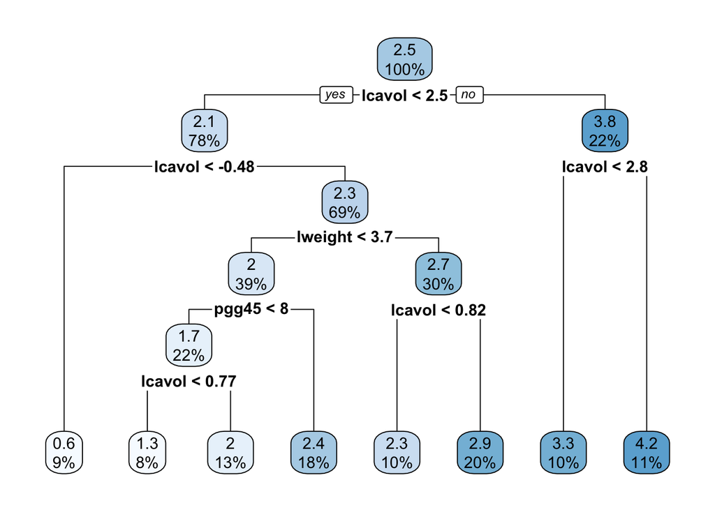

```r
rpart.plot(tree_fit_1$finalModel)
```

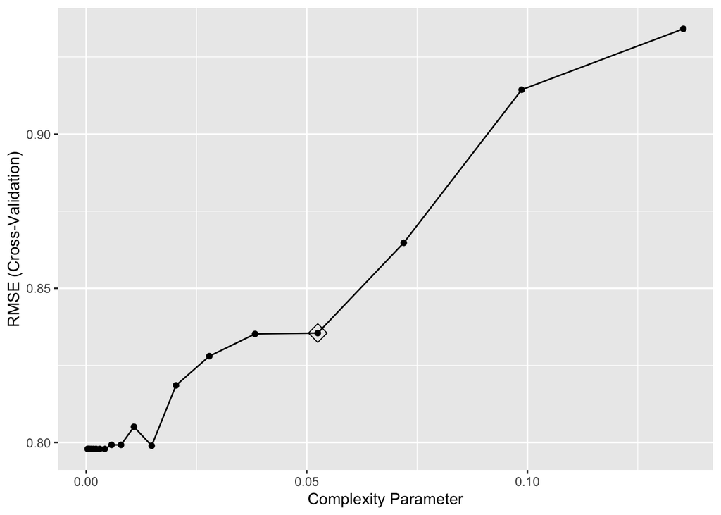

```r
# 1 SE rule
set.seed(1)
tree_fit_2 = train(lpsa~.,
                   data = Prostate,
                   method = "rpart",
                   tuneGrid = data.frame(cp = exp(seq(-8, -2, length = 20))),
                   trControl = trainControl(method = "cv",
                                            number = 10,
                                            selectionFunction = "oneSE"))

ggplot(tree_fit_2, highlight = TRUE)
```

```r
tree_fit_2$finalModel$cptable
```

```
##           CP nsplit rel error
## 1 0.34710828      0 1.0000000
## 2 0.18464743      1 0.6528917
## 3 0.05931585      2 0.4682443
## 4 0.05247762      3 0.4089284
```

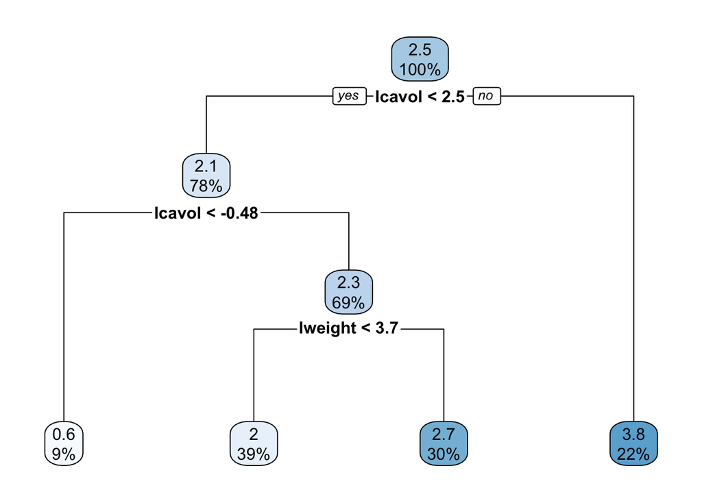

```r
rpart.plot(tree_fit_2$finalModel)
```

The regression trees from lowest CV and 1 SE rule are different.

## B. Choose the decision tree

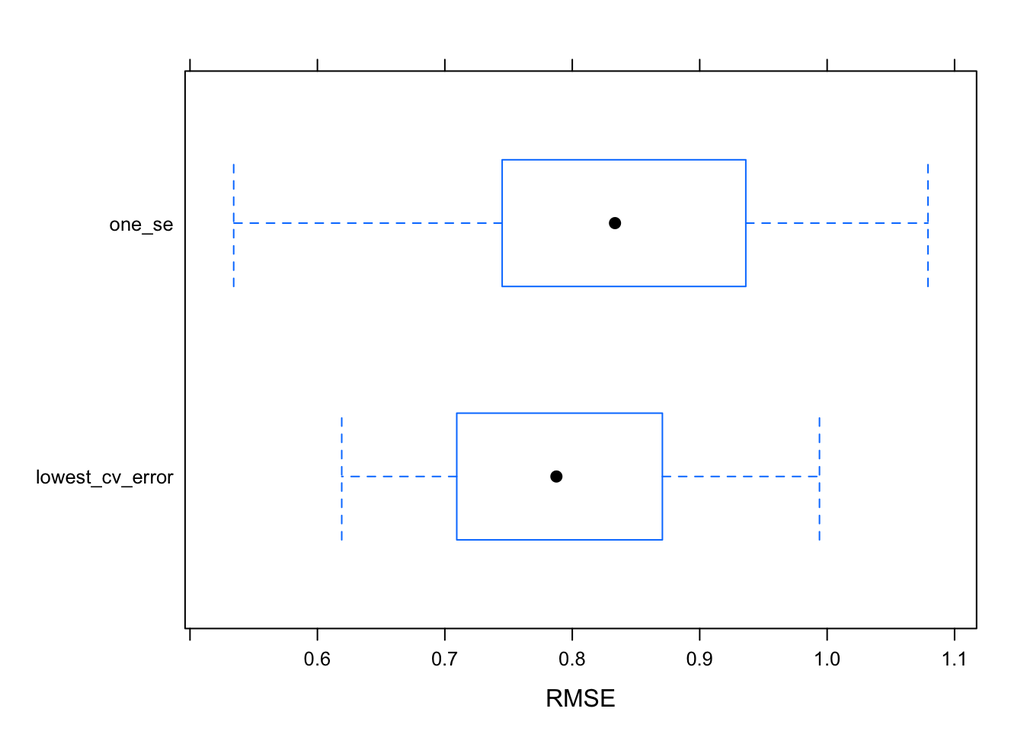

```r
resamp = resamples(list(lowest_cv_error = tree_fit_1,
                         one_se = tree_fit_2
                         ))

bwplot(resamp, metric = "RMSE")
```

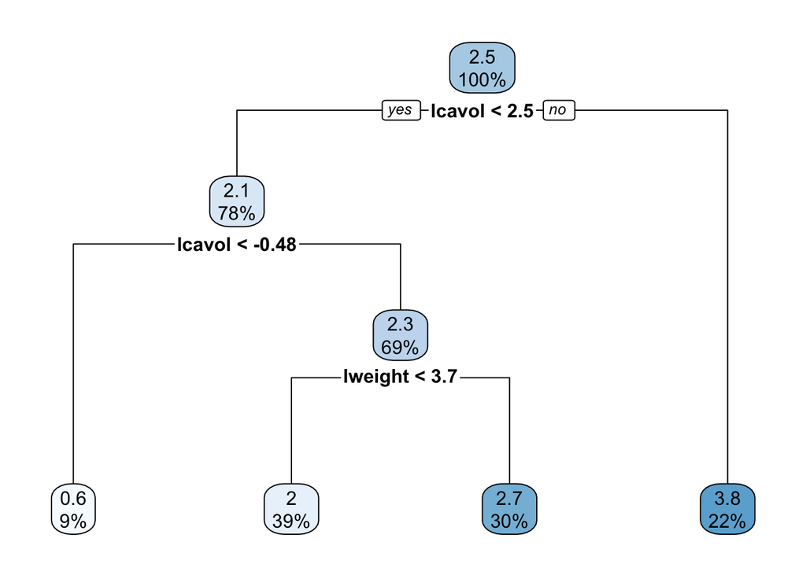

```r
rpart.plot(tree_fit_2$finalModel)
```

For the terminal node lcavol < 2.5, if log(cancer volumn) is smaller than 2.5, there is 78% of probability that log(prostate specific antigen) to be 2.1. If lcovol is not smaller than 2.5, there is 22% of probability that lpsa to be 3.8.

## C. Bagging

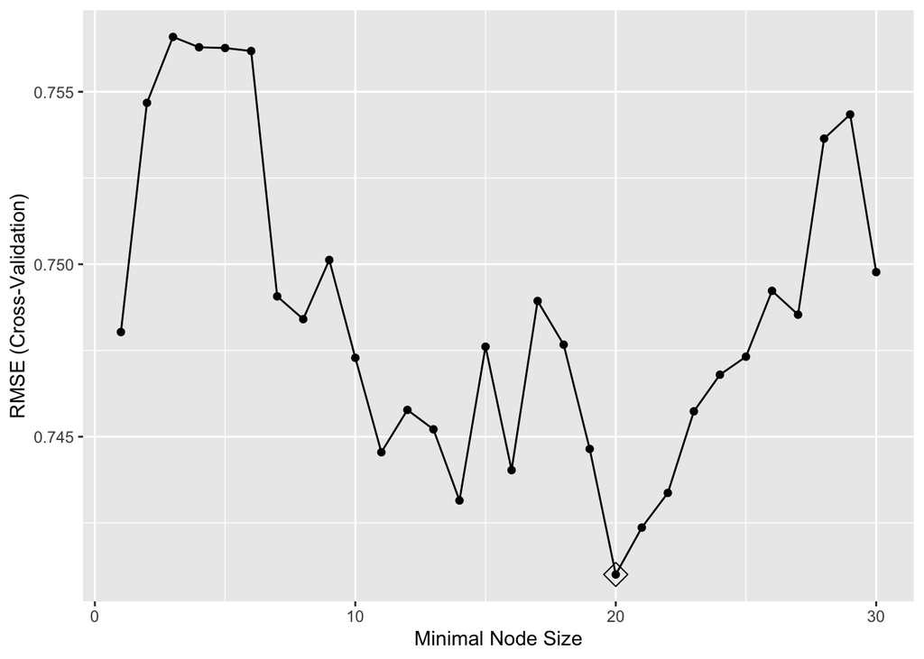

```r
set.seed(1)
bagging.grid = expand.grid(mtry = 8,
                           splitrule = "variance",
                           min.node.size = 1:30)
bag_fit = train(lpsa~.,
                data = Prostate,
                method = "ranger",
                tuneGrid = bagging.grid,
                importance = "impurity",
                trControl = trainControl(method = "cv"))

ggplot(bag_fit, highlight = TRUE)
```

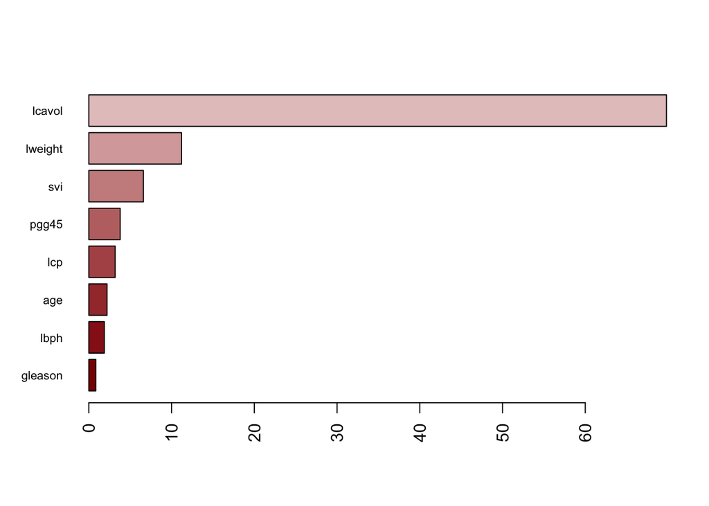

```r
barplot(sort(ranger::importance(bag_fit$finalModel), decreasing = FALSE),
        las = 2, horiz = TRUE, cex.names = 0.7,
        col = colorRampPalette(colors = c("darkred","white","darkblue"))(19))
```

Variable Importance: lcavol > lweight > svi > pgg45 > lcp > age > lbph > gleason

## D. Random Forests

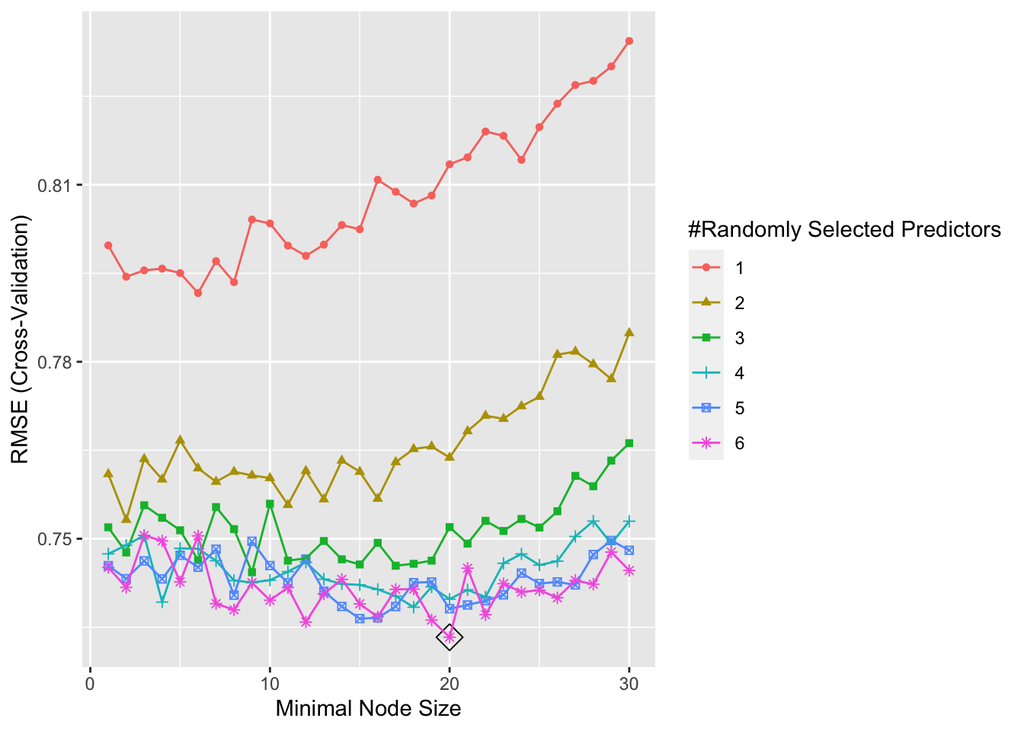

```r
set.seed(1)
rf.grid = expand.grid(mtry = 1:6, splitrule = "variance", min.node.size = 1:30)

rf_fit = train(lpsa~.,
               data = Prostate,
               method = "ranger",
               tuneGrid = rf.grid,
               importance = "impurity",
               trControl = trainControl(method = "cv"))

ggplot(rf_fit, highlight = TRUE)
```

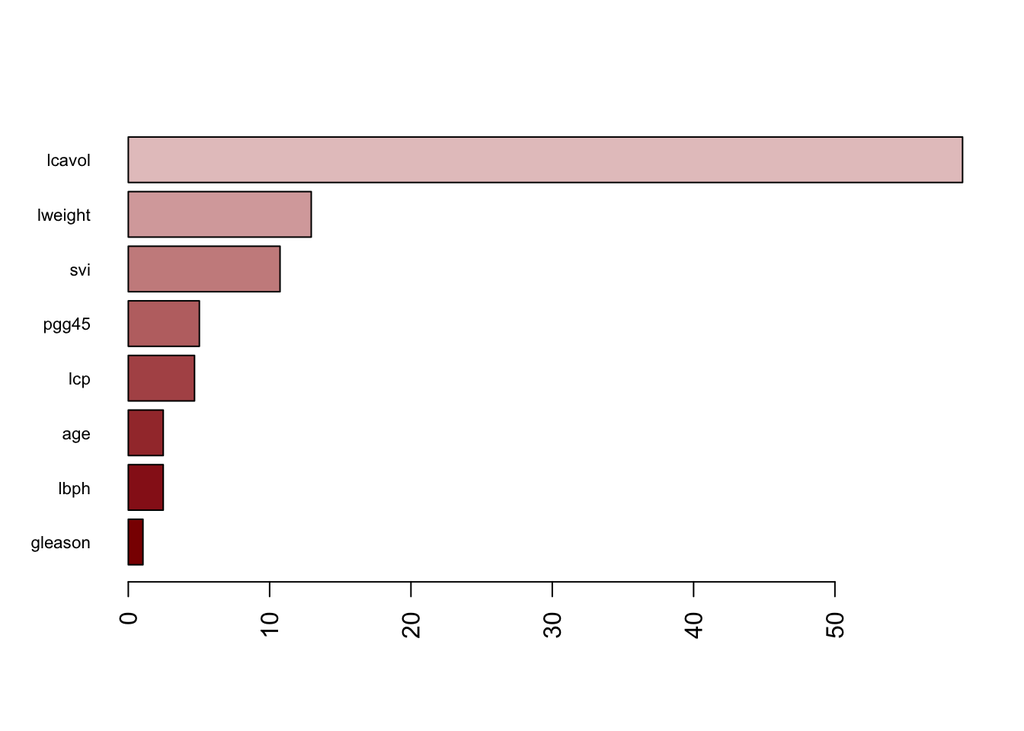

```r
barplot(sort(ranger::importance(rf_fit$finalModel), decreasing = FALSE),
        las = 2, horiz = TRUE, cex.names = 0.7,
        col = colorRampPalette(colors = c("darkred","white","darkblue"))(19))
```

## E. Boosting

```r
set.seed(1)

gbm.grid = expand.grid(n.trees = seq(1,5001, by = 500),
                       interaction.depth = 1:10,
                       shrinkage = c(0.001, 0.003, 0.005),
                       n.minobsinnode = 1)

gbm_fit = train(lpsa~.,
                data = Prostate,
                method = "gbm",
                tuneGrid = gbm.grid,
                trControl = trainControl(method = "cv"),
                verbose = FALSE)
```

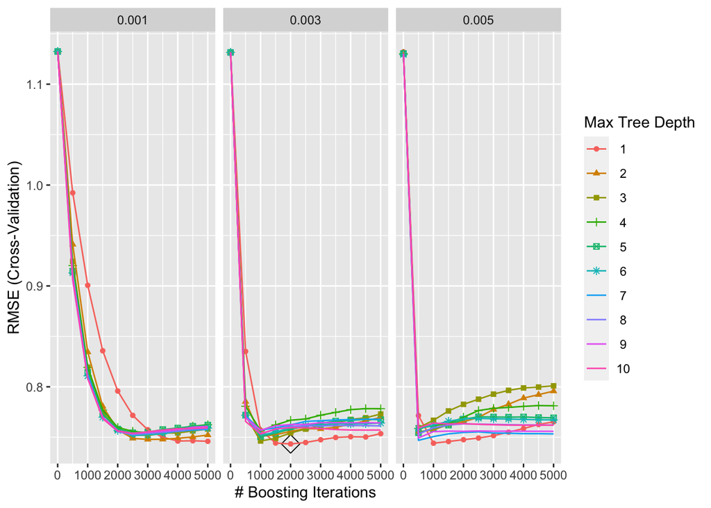

```r
ggplot(gbm_fit, highlight = TRUE)
```

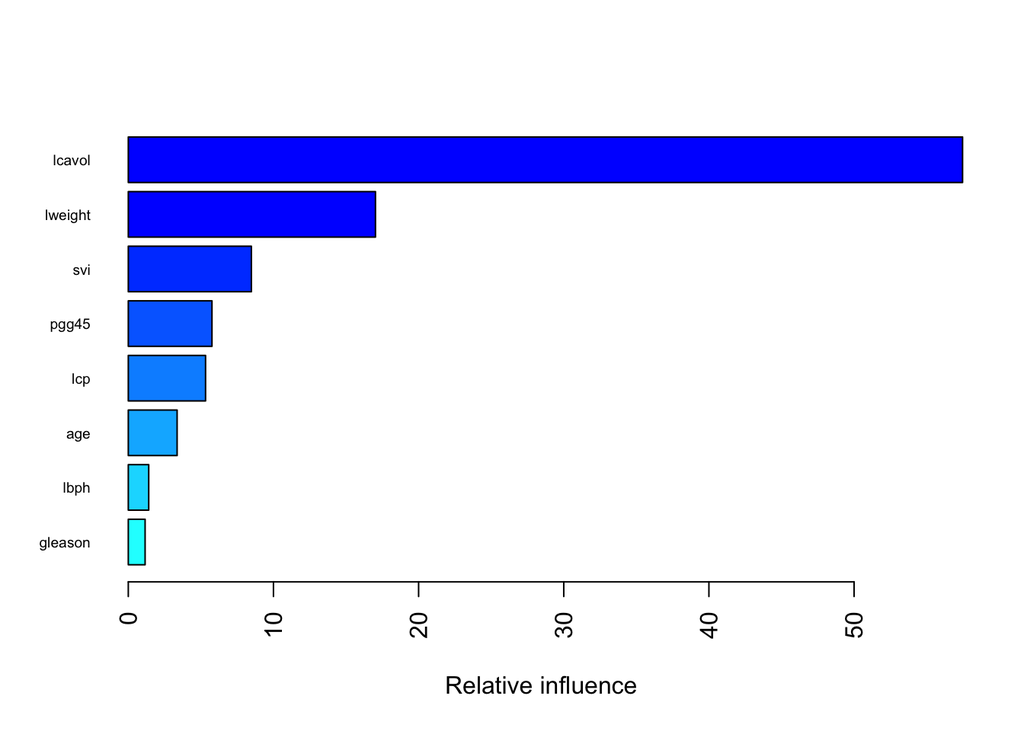

```
##             var   rel.inf
## lcavol   lcavol 57.474056
## lweight lweight 17.027933
## svi         svi  8.479331
## pgg45     pgg45  5.765356
## lcp         lcp  5.323152
## age         age  3.363850
## lbph       lbph  1.407875
## gleason gleason  1.158447
```

```r
summary(gbm_fit$finalModel, las = 2, cBars = 19, cex.names = 0.6)
```

## F. Comparisons

```r
resamp_2 = resamples(list(tree_fit = tree_fit_1,
                          tree_fit_1SE = tree_fit_2,
                          bagging = bag_fit,
                          randomforest = rf_fit,
                          boosting = gbm_fit))

summary(resamp_2)
```

```
##
## Call:
## summary.resamples(object = resamp_2)
##
## Models: tree_fit, tree_fit_1SE, bagging, randomforest, boosting
## Number of resamples: 10
##
## MAE
##                   Min.   1st Qu.    Median      Mean   3rd Qu.      Max. NA's
## tree_fit     0.5293632 0.5729342 0.6481657 0.6633928 0.7207664 0.8777953    0
## tree_fit_1SE 0.4357075 0.5706012 0.7067185 0.6796373 0.7977977 0.8703550    0
## bagging      0.4433892 0.5506423 0.6187773 0.6028693 0.6563489 0.7295966    0
## randomforest 0.4554822 0.5436194 0.6180317 0.5994308 0.6636039 0.7080718    0
## boosting     0.4878801 0.5540710 0.6053314 0.6008631 0.6381473 0.6978078    0
##
## RMSE
##                   Min.   1st Qu.    Median      Mean   3rd Qu.      Max. NA's
## tree_fit     0.6190744 0.7169931 0.7875436 0.7979146 0.8638012 0.9939908    0
## tree_fit_1SE 0.5342864 0.7457950 0.8335274 0.8354868 0.9237662 1.0791335    0
## bagging      0.5332508 0.6602017 0.7460857 0.7410050 0.8218336 0.9104530    0
## randomforest 0.5435114 0.6387862 0.7393165 0.7333067 0.8108179 0.9294960    0
## boosting     0.5984236 0.6748127 0.7519523 0.7433897 0.7848678 0.9074745    0
##
## Rsquared
##                    Min.   1st Qu.    Median      Mean   3rd Qu.      Max. NA's
## tree_fit     0.11990318 0.3945387 0.5620070 0.5332883 0.7161215 0.7679649    0
## tree_fit_1SE 0.04643869 0.4688282 0.5393638 0.5061726 0.6050400 0.7639059    0
## bagging      0.41035904 0.5274679 0.6165821 0.6181705 0.7020880 0.7821978    0
## randomforest 0.37094854 0.5517331 0.6145224 0.6207200 0.7081548 0.7822906    0
## boosting     0.37405448 0.5056192 0.6369519 0.6223847 0.7392506 0.8362165    0
```

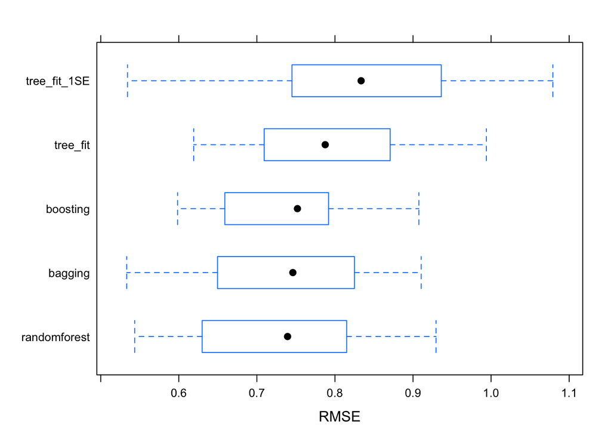

```r
bwplot(resamp_2, metric = "RMSE")
```

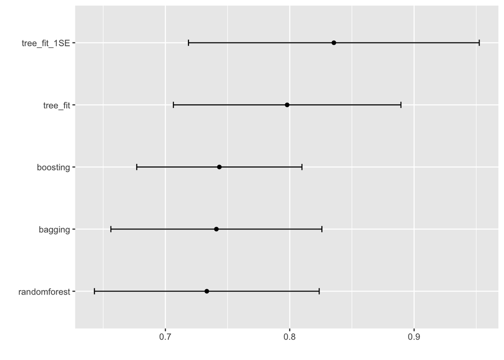

```r
ggplot(resamp_2, metric = "RMSE")
```

# Problem 2

## A. Decision Tree

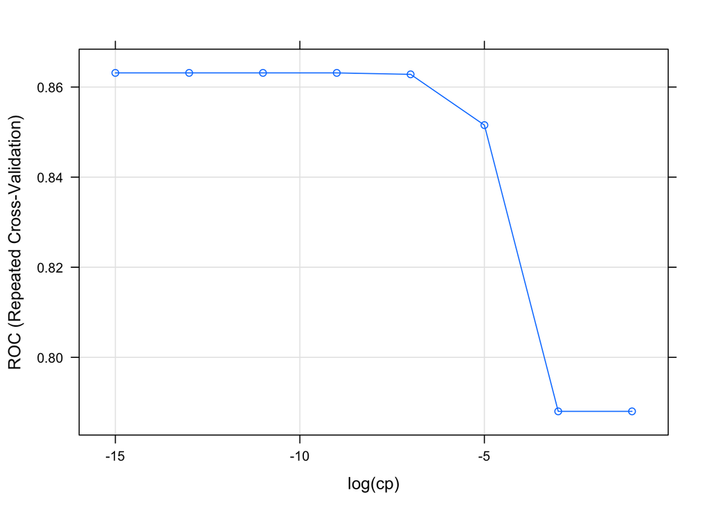

```r
set.seed(1)
trainindex = sample(seq_len(nrow(OJ)), size = 800)
train = OJ[trainindex, ]
test = OJ[-trainindex, ]

ctrl2 = trainControl(method = "repeatedcv", summaryFunction = twoClassSummary, classProbs = TRUE)

rpart_fit_c = train(Purchase~.,
                    data = train,
                    method = "rpart",
                    tuneGrid = data.frame(cp = exp(seq(-15,0, by = 2))),
                    trControl = ctrl2,
                    metric = "ROC")

plot(rpart_fit_c, xTrans = function(x)log(x), xlab = "log(cp)")
```

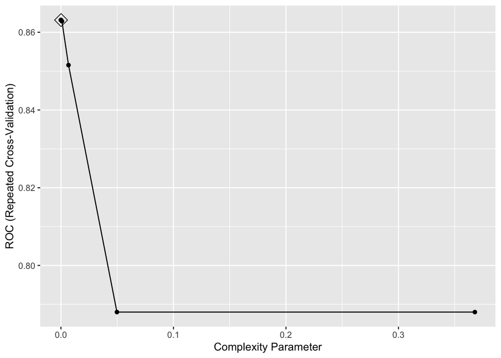

```r
ggplot(rpart_fit_c, highlight = TRUE)
```

```r
rpart_fit_c$bestTune
```

```
##             cp
## 4 0.0001234098
```

```r
rpart_fit_c$finalModel$cptable
```

```
##            CP nsplit rel error
## 1 0.504761905      0 1.0000000
## 2 0.019047619      1 0.4952381
## 3 0.015873016      4 0.4253968
## 4 0.012698413      6 0.3936508
## 5 0.007936508      8 0.3682540
## 6 0.003174603     10 0.3523810
## 7 0.000000000     19 0.3238095
```

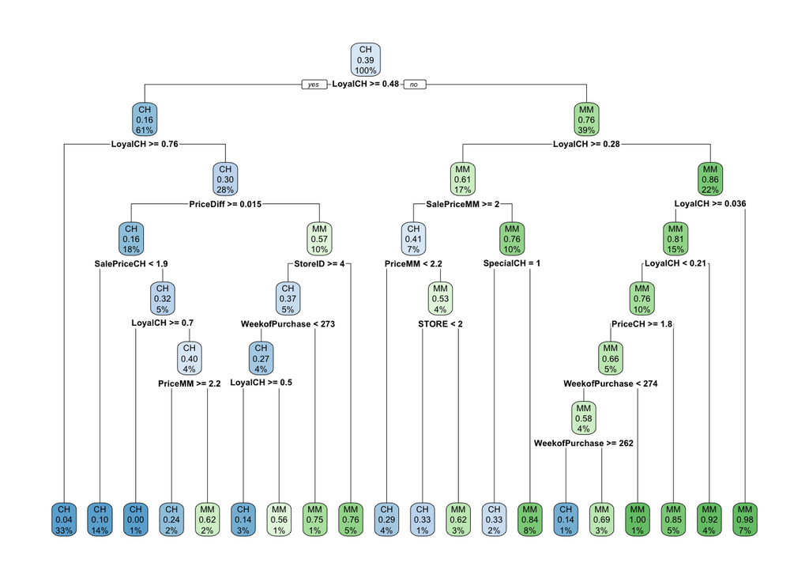

```r
rpart.plot(rpart_fit_c$finalModel) # final tree
```

```r
tree.pred = predict(rpart_fit_c, newdata = test, type = "raw")
1 - sum(tree.pred == test$Purchase) / length(test$Purchase)
```

```
## [1] 0.1740741
```

The final tree has a size of 20. The test classification error rate is 17.40741%.

## B. Random forests

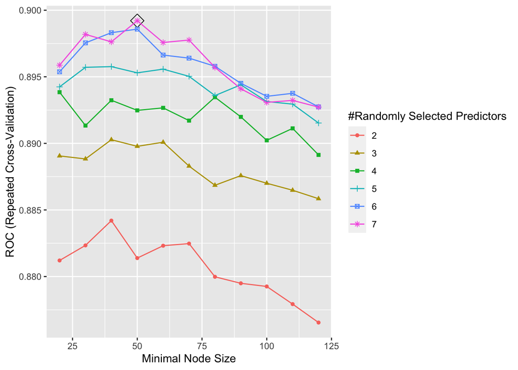

```r
set.seed(1)

rf.grid2 = expand.grid(mtry = 2:7,
                       splitrule = "gini",
                       min.node.size = seq(20,120, by = 10))

rf_fit_c = train(Purchase~.,
                 data = train,
                 method = "ranger",
                 tuneGrid = rf.grid2,
                 metric = "ROC",
                 trControl = ctrl2,
                 importance = "impurity")

ggplot(rf_fit_c, highlight = TRUE)
```

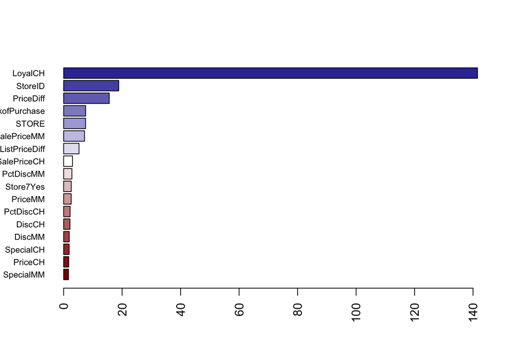

```r
barplot(sort(ranger::importance(rf_fit_c$finalModel),
             decreasing = FALSE),
        las = 2, horiz = TRUE, cex.names = 0.7,
        col = colorRampPalette(colors = c("darkred","white","darkblue"))(19))
```

```r
rf.pred = predict(rf_fit_c, newdata = test, type = "raw")
1 - sum(rf.pred == test$Purchase) / length(test$Purchase)
```

```
## [1] 0.1555556
```

Variables Importance: LoyalCH > StoreID > PriceDiff > WeekofPurchase > STORE > SalePriceMM > ListPriceDiff > SalePriceCH > PctDiscMM > Store7Yes > PriceMM > PctDiscCH > DiscCH > DiscMM > SpecialCH > PriceCH > SpecialMM

The test classification error rate is 15.55556%.

## C. Boosting

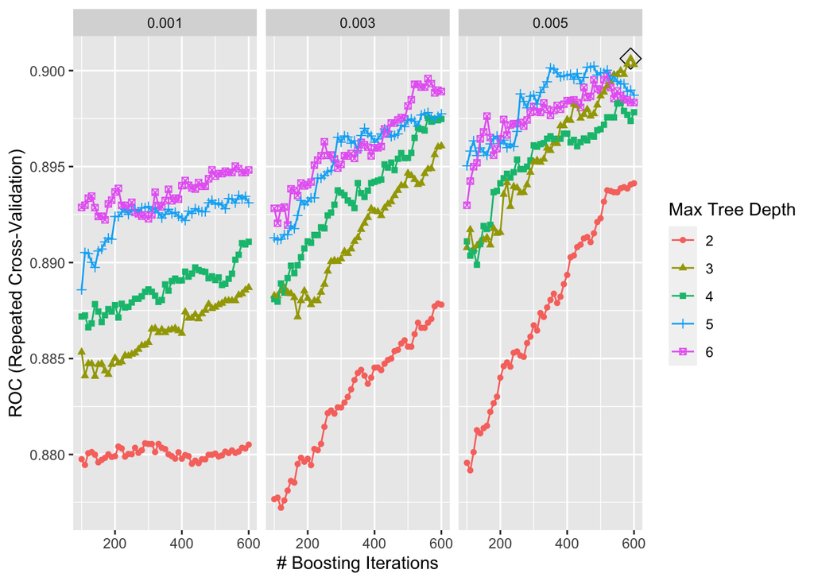

```r
set.seed(1)

gbm.grid2 = expand.grid(n.trees = seq(100, 600, by = 10),
                        interaction.depth = 2:6,
                        shrinkage = c(0.001, 0.003, 0.005),
                        n.minobsinnode = 1)

gbm_fit_c = train(Purchase~.,
                  data = train,
                  method = "gbm",
                  trControl = ctrl2,
                  distribution = "bernoulli",
                  metric = "ROC",
                  tuneGrid = gbm.grid2,
                  verbose = FALSE)

ggplot(gbm_fit_c, highlight = TRUE)
```

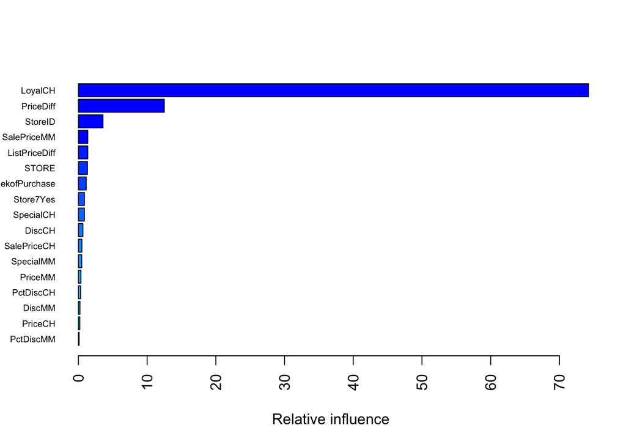

```
##                           var     rel.inf
## LoyalCH               LoyalCH 74.22830481
## PriceDiff           PriceDiff 12.49205624
## StoreID               StoreID  3.57325524
## SalePriceMM       SalePriceMM  1.35851284
## ListPriceDiff   ListPriceDiff  1.35758575
## STORE                   STORE  1.31022443
## WeekofPurchase WeekofPurchase  1.12749681
## Store7Yes           Store7Yes  0.87075899
## SpecialCH           SpecialCH  0.86256345
## DiscCH                 DiscCH  0.65375379
## SalePriceCH       SalePriceCH  0.49881674
## SpecialMM           SpecialMM  0.47598488
## PriceMM               PriceMM  0.35894394
## PctDiscCH           PctDiscCH  0.31760056
## DiscMM                 DiscMM  0.21832256
## PriceCH               PriceCH  0.20205071
## PctDiscMM           PctDiscMM  0.09376827
```

```r
summary(gbm_fit_c$finalModel, las = 2, cBars = 19, cex.names = 0.6)
```

```r
gbm.pred = predict(gbm_fit_c, newdata = test, type = "raw")
1 - sum(gbm.pred == test$Purchase) / length(test$Purchase)
```

```
## [1] 0.1481481
```

Variable Importance: LoyalCH > PriceDiff > StoreID > SalePriceMM > ListPriceDiff > STORE > WeekofPurchase > Store7Yes > SpecialCH > DiscCH > SalePriceCH > SpecialMM > PriceMM > PctDiscCH > DiscMM > PriceCH > PctDiscMM

The test classification error rate is 14.81481%.